# Лабораторна Робота №2

## Тема: Налаштування Python/DS середовищ (Miniconda)

### Мета: Сформувати правильну ментальну модель роботи з Python-середовищами та навчитися будувати відтворюване, кероване і масштабоване середовище для загальних python-проєктів та Data Science і Machine Learning.

#### Виконав: Гнатюк Євгеній

# Порядок виконання роботи

1. Вимкнув системний Python.
2. Встановив Miniconda без додавання до PATH.
3. Налаштував канали: conda-forge та увімкнув strict channel priority
4. Створив базові середовища:  
   • py311 (Python 3.11)  
   • py312 (Python 3.12)
5. Створив базові шаблонні середовища:  
   • ds-base-2026.1  
   • py-dev-base
6. Створив проєктне середовище:  
   • asd (клон від ds-base-2026.1)
7. Зареєстрував kernel через ipykernel.
8. Підключив середовище в JupyterLab.

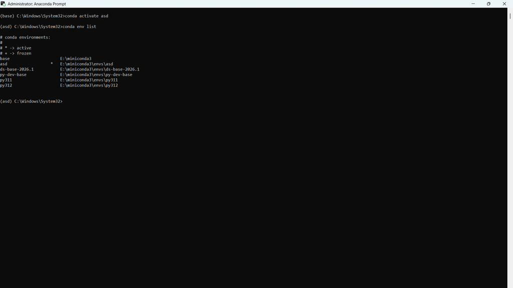

# Висновок

У результаті роботи я навчився працювати в середовищі Miniconda та Jupyter Notebook.

# Контрольні запитання:

1. Чому не рекомендується використовувати системний Python у Windows? Щоб уникнути конфліктів версій та не засмічувати операційну систему пакетами, які можуть порушити роботу інших програм або фонових утиліт.
2. Навіщо створювати окреме середовище для кожного проєкту? Це створює ізольовані "контейнери". Вони гарантують, що проєкт не зламається через оновлення в іншому проєкті, а сам код можна буде легко перенести та запустити на іншому комп'ютері.
3. У чому різниця між базовим середовищем і проєктним? Базове середовище (base) — це ядро самого менеджера пакетів (наприклад, Conda), і в ньому краще не працювати, щоб випадково не зламати саму програму. Проєктне — це чисте, ізольоване середовище, яке ви створюєте виключно під конкретне завдання.
4. Для чого використовується environment.yml? Це файл-конфігурація (для Conda), у якому записаний точний список усіх встановлених бібліотек та їхніх версій. Він дозволяє іншій людині або вам на іншому ПК відтворити ідентичне середовище однією командою.
5. Як перевірити, який Python використовується в ноутбуці? Запустити код:

```python
import sys
print(sys.executable)
```

```
E:\miniconda3\envs\asd\python.exe
```